# Project Python Foundations: FoodHub Data Analysis

**Marks: 60**

### Context

The number of restaurants in New York is increasing day by day. Lots of students and busy professionals rely on those restaurants due to their hectic lifestyles. Online food delivery service is a great option for them. It provides them with good food from their favorite restaurants. A food aggregator company FoodHub offers access to multiple restaurants through a single smartphone app.

The app allows the restaurants to receive a direct online order from a customer. The app assigns a delivery person from the company to pick up the order after it is confirmed by the restaurant. The delivery person then uses the map to reach the restaurant and waits for the food package. Once the food package is handed over to the delivery person, he/she confirms the pick-up in the app and travels to the customer's location to deliver the food. The delivery person confirms the drop-off in the app after delivering the food package to the customer. The customer can rate the order in the app. The food aggregator earns money by collecting a fixed margin of the delivery order from the restaurants.

### Objective

The food aggregator company has stored the data of the different orders made by the registered customers in their online portal. They want to analyze the data to get a fair idea about the demand of different restaurants which will help them in enhancing their customer experience. Suppose you are hired as a Data Scientist in this company and the Data Science team has shared some of the key questions that need to be answered. Perform the data analysis to find answers to these questions that will help the company to improve the business.

### Data Description

The data contains the different data related to a food order. The detailed data dictionary is given below.

### Data Dictionary

- order_id: Unique ID of the order
- customer_id: ID of the customer who ordered the food
- restaurant_name: Name of the restaurant
- cuisine_type: Cuisine ordered by the customer
- cost: Cost of the order
- day_of_the_week: Indicates whether the order is placed on a weekday or weekend (The weekday is from Monday to Friday and the weekend is Saturday and Sunday)
- rating: Rating given by the customer out of 5
- food_preparation_time: Time (in minutes) taken by the restaurant to prepare the food. This is calculated by taking the difference between the timestamps of the restaurant's order confirmation and the delivery person's pick-up confirmation.
- delivery_time: Time (in minutes) taken by the delivery person to deliver the food package. This is calculated by taking the difference between the timestamps of the delivery person's pick-up confirmation and drop-off information

### Let us start by importing the required libraries

```python
# import libraries for data manipulation
import numpy as np
import pandas as pd

# import libraries for data visualization
import matplotlib.pyplot as plt
import seaborn as sns

%matplotlib inline
```

### Understanding the structure of the data

```python
# uncomment and run the following lines for Google Colab
from google.colab import drive
drive.mount('/content/drive')
```

```python
path="/content/drive/MyDrive/Job Search/UT DAE /Python/Project/foodhub_order.csv"
# read the data
df = pd.read_csv(path)
# returns the first 5 rows
df.head()
```

|  | order_id | customer_id | restaurant_name | cuisine_type | cost_of_the_order | day_of_the_week | rating | food_preparation_time | delivery_time |
| --- | --- | --- | --- | --- | --- | --- | --- | --- | --- |
| 0 | 1477147 | 337525 | Hangawi | Korean | 30.75 | Weekend | Not given | 25 | 20 |
| 1 | 1477685 | 358141 | Blue Ribbon Sushi Izakaya | Japanese | 12.08 | Weekend | Not given | 25 | 23 |
| 2 | 1477070 | 66393 | Cafe Habana | Mexican | 12.23 | Weekday | 5 | 23 | 28 |
| 3 | 1477334 | 106968 | Blue Ribbon Fried Chicken | American | 29.20 | Weekend | 3 | 25 | 15 |
| 4 | 1478249 | 76942 | Dirty Bird to Go | American | 11.59 | Weekday | 4 | 25 | 24 |

```python
from google.colab import drive
drive.mount('/content/drive')
```

#### Observations:

The DataFrame has 9 columns as mentioned in the Data Dictionary. Data in each row corresponds to the order placed by a customer.

### **Question 1:** How many rows and columns are present in the data? [0.5 mark]

```python
df.shape
```

```
(1898, 9)
```

#### Observations:

The DataFrame has 9 columns and 1898 rows that corresponds to each order placed using the service.

### **Question 2:** What are the datatypes of the different columns in the dataset? (The info() function can be used) [0.5 mark]

```python
df.info()
```

```
<class 'pandas.core.frame.DataFrame'>
RangeIndex: 1898 entries, 0 to 1897
Data columns (total 9 columns):
 #   Column                 Non-Null Count  Dtype
---  ------                 --------------  -----
 0   order_id               1898 non-null   int64
 1   customer_id            1898 non-null   int64
 2   restaurant_name        1898 non-null   object
 3   cuisine_type           1898 non-null   object
 4   cost_of_the_order      1898 non-null   float64
 5   day_of_the_week        1898 non-null   object
 6   rating                 1898 non-null   object
 7   food_preparation_time  1898 non-null   int64
 8   delivery_time          1898 non-null   int64
dtypes: float64(1), int64(4), object(4)
memory usage: 133.6+ KB
```

#### Observations:

Three data types are present in the data frame, float, interger, and object.There is one float data type in the data which is the 'cost_of_the_order' column. Four integer data types which are 'order_id', 'customer_id', 'food_preparation_time', 'delivery_time'. Objects include 'restaurant_name', 'cuisine_type', 'day_of_the_week', and 'rating'. Rating is oddly assigned an object datatype.

### **Question 3:** Are there any missing values in the data? If yes, treat them using an appropriate method. [1 mark]

```python
df.isnull().sum()
```

```
order_id                 0
customer_id              0
restaurant_name          0
cuisine_type             0
cost_of_the_order        0
day_of_the_week          0
rating                   0
food_preparation_time    0
delivery_time            0
dtype: int64
```

#### Observations:

There are no missing or null values within the data frame.

### **Question 4:** Check the statistical summary of the data. What is the minimum, average, and maximum time it takes for food to be prepared once an order is placed? [2 marks]

```python
df.describe().T
```

|  | count | mean | std | min | 25% | 50% | 75% | max |
| --- | --- | --- | --- | --- | --- | --- | --- | --- |
| order_id | 1898.0 | 1.477496e+06 | 548.049724 | 1476547.00 | 1477021.25 | 1477495.50 | 1.477970e+06 | 1478444.00 |
| customer_id | 1898.0 | 1.711685e+05 | 113698.139743 | 1311.00 | 77787.75 | 128600.00 | 2.705250e+05 | 405334.00 |
| cost_of_the_order | 1898.0 | 1.649885e+01 | 7.483812 | 4.47 | 12.08 | 14.14 | 2.229750e+01 | 35.41 |
| food_preparation_time | 1898.0 | 2.737197e+01 | 4.632481 | 20.00 | 23.00 | 27.00 | 3.100000e+01 | 35.00 |
| delivery_time | 1898.0 | 2.416175e+01 | 4.972637 | 15.00 | 20.00 | 25.00 | 2.800000e+01 | 33.00 |

#### Observations:

The minimum time it takes to for food to be prepared is 20 minutes, while the maximum time it takes is 35 minutes. Overall, the average amount of time it takes to prepare food once ordered is 27.37 minutes.

### **Question 5:** How many orders are not rated? [1 mark]

```python
# Write the code here
df['rating'].value_counts()
```

```
Not given    736
5            588
4            386
3            188
Name: rating, dtype: int64
```

#### Observations:

Of the 1898 orders, 736 were not rated.

### Exploratory Data Analysis (EDA)

### **Question 6:** Explore all the variables and provide observations on their distributions. (Generally, histograms, boxplots, countplots, etc. are used for univariate exploration.) [9 marks]

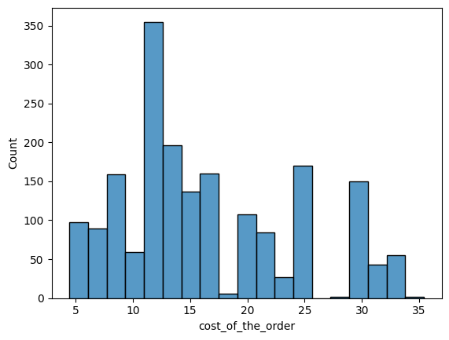

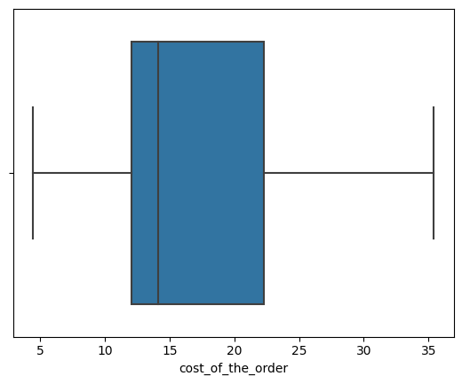

```python
sns.histplot(data=df, x='cost_of_the_order')
plt.show()
sns.boxplot(data=df, x='cost_of_the_order')
plt.show()
```

Observation:

The order cost does not have any outliers. The plots are skewes to the right, however, 50% of the cost of food is below $15.

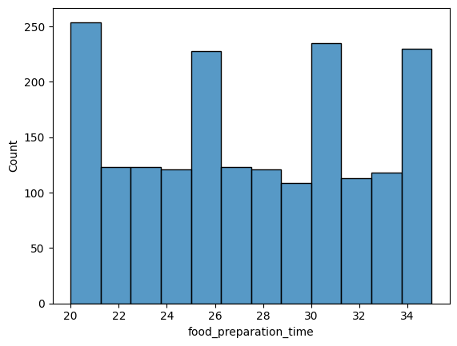

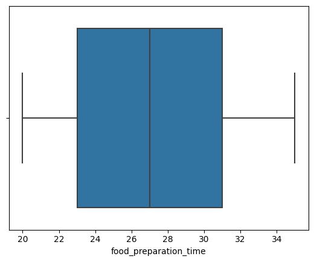

```python
sns.histplot(data=df, x='food_preparation_time')
plt.show()
sns.boxplot(data=df, x='food_preparation_time')
plt.show()
```

Observation:

The box plot would appear to be normally distributed, however, the histogram has no noticeable shape with four peaks evenly distributed in a flat manner.

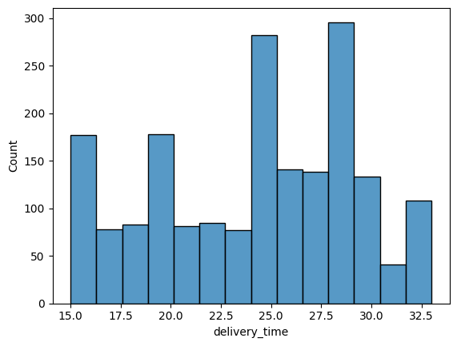

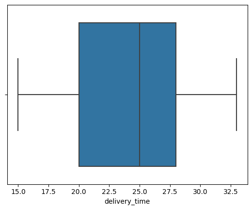

```python
sns.histplot(data=df,x='delivery_time')
plt.show()
sns.boxplot(data=df,x='delivery_time')
plt.show()
```

Observation:

The plots are slightly skewed to the left with 50% of the delivery times being 25 minutes or less.

```
(array([ 0,  1,  2,  3,  4,  5,  6,  7,  8,  9, 10, 11, 12, 13]),
 [Text(0, 0, 'Korean'),
```

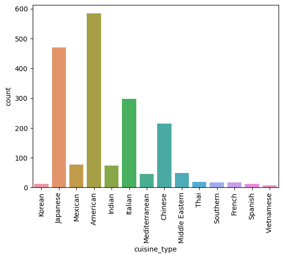

```python
sns.countplot(data=df,x='cuisine_type')
plt.xticks(rotation=90)
```

Observation:

American food has the highest count with nearly 600 orders. Japanese, Italian, and Chinese (respectively) also had noticeably high peaks relative to the rest.

```
(array([ 0,  1,  2,  3,  4,  5,  6,  7,  8,  9, 10, 11, 12, 13, 14, 15, 16,
        17, 18, 19, 20, 21, 22, 23, 24, 25, 26, 27, 28, 29]),
 [Text(0, 0, 'Shake Shack'),
```

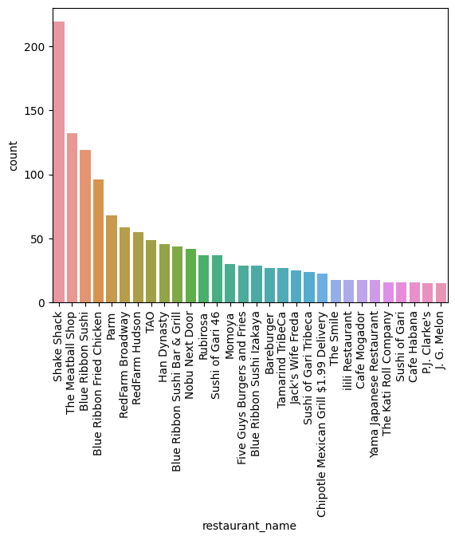

```python
sns.countplot(data=df,x='restaurant_name',order=df.restaurant_name.value_counts().iloc[:30].index)
plt.xticks(rotation=90)
#limited the amount of restaurants shown for a more clean visual
```

Observation:

Shake shack was the top ordered from restaurant by a wide margin.

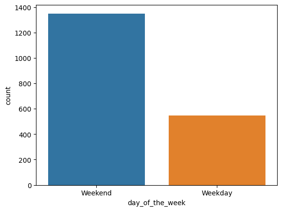

```python
sns.countplot(data=df,x='day_of_the_week')
```

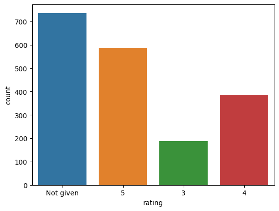

```python
sns.countplot(data=df,x='rating')
```

### **Question 7**: Which are the top 5 restaurants in terms of the number of orders received? [1 mark]

```python
# value_sort to get the count of each restaurant
df['restaurant_name'].value_counts().sort_values(ascending=False)
```

```
Shake Shack                  219
The Meatball Shop            132
Blue Ribbon Sushi            119
Blue Ribbon Fried Chicken     96
Parm                          68
                            ...
Coppola's East                 1
Kori Restaurant and Bar        1
Woorijip                       1
Crema Restaurante              1
'wichcraft                     1
Name: restaurant_name, Length: 178, dtype: int64
```

#### Observations:

The top five restaurants by order, in descending order, Shake Shack, The Meatball Shop, Blue Ribbon Sushi, Blue Ribbon Fried Chicken, and Parm.

### **Question 8**: Which is the most popular cuisine on weekends? [1 mark]

```python
# groupby the day of the week and do a value_counts to get the total count
df.groupby(['day_of_the_week'])['cuisine_type'].value_counts()
```

```
day_of_the_week  cuisine_type
Weekday          American          169
                 Japanese          135
                 Italian            91
                 Chinese            52
                 Indian             24
                 Mexican            24
                 Middle Eastern     17
                 Mediterranean      14
                 Southern            6
                 French              5
                 Thai                4
                 Vietnamese          3
                 Korean              2
                 Spanish             1
Weekend          American          415
                 Japanese          335
                 Italian           207
                 Chinese           163
                 Mexican            53
                 Indian             49
                 Mediterranean      32
                 Middle Eastern     32
                 Thai               15
                 French             13
                 Korean             11
                 Southern           11
                 Spanish            11
                 Vietnamese          4
Name: cuisine_type, dtype: int64
```

#### Observations:

The most popular cuisine type on the weekends is 'American' with 415 orders.

### **Question 9**: What percentage of the orders cost more than 20 dollars? [2 marks]

```python
# isolate the order costs higher than 20
# find the lenght(amount of orders) and find the percentage
greater_than_twenty=df.loc[df['cost_of_the_order']>20]
(len(greater_than_twenty)/len(df))*100
```

```
29.24130663856691
```

#### Observations:

Of the total amount of orders, 29.24% cost more than 20 dollars.

### **Question 10**: What is the mean order delivery time? [1 mark]

```python
df['delivery_time'].mean()
```

```
24.161749209694417
```

#### Observations:

The mean order delivery time is 24.2 minutes.

### **Question 11:** The company has decided to give 20% discount vouchers to the top 5 most frequent customers. Find the IDs of these customers and the number of orders they placed. [1 mark]

```python
df['customer_id'].value_counts().sort_values(ascending=False)
```

```
52832     13
47440     10
83287      9
250494     8
259341     7
          ..
335897     1
377481     1
125542     1
288808     1
397537     1
Name: customer_id, Length: 1200, dtype: int64
```

#### Observations:

The top five IDs are 52832, 47440, 83287, 250494, and 259341 with 13, 10, 9, 8 , 7 orders placed, respectively.

### **Question 12**: Perform a multivariate analysis to explore relationships between the important variables in the dataset. (It is a good idea to explore relations between numerical variables as well as relations between numerical and categorical variables) [10 marks]

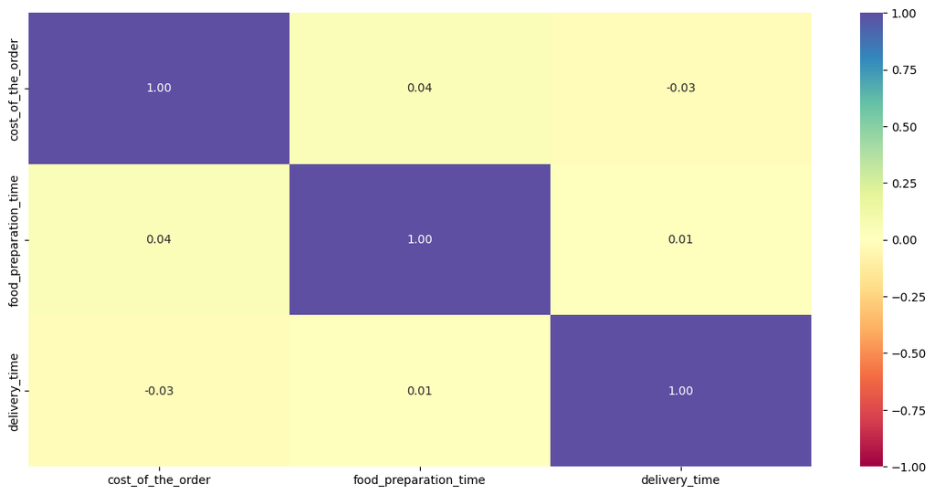

```python
# Write the code here
nv = ['cost_of_the_order','rating','food_preparation_time','delivery_time']
corr = df[nv].corr()

plt.figure(figsize=(15,7))
sns.heatmap(corr, annot=True,vmin=-1, vmax=1, fmt=".2f", cmap="Spectral")
plt.show()
```

Observation:

There does not seem to be any strong correlation between any of the numerical variables.

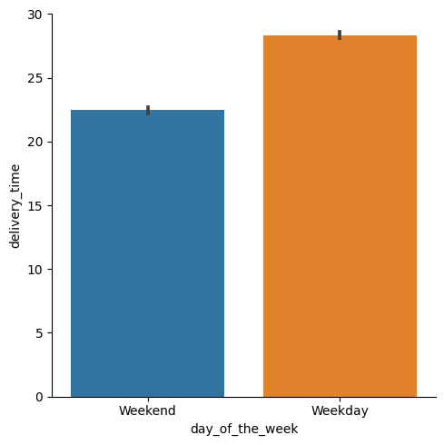

```python
sns.catplot(data=df,x='day_of_the_week',y='delivery_time', kind='bar' )
plt.show()
```

Observation:

There are higher delivery times on the weekdays than the weekends.

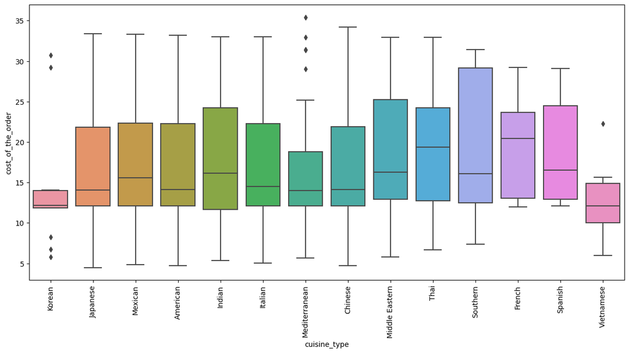

```python
plt.figure(figsize=(15,7))
sns.boxplot(data=df,x='cuisine_type',y='cost_of_the_order')
plt.xticks(rotation=90)
plt.show()
```

Observation:

The majority of cuisines have similar ranges of costs with one another. Korean, Mediterranean, and Vietnamese have outliers

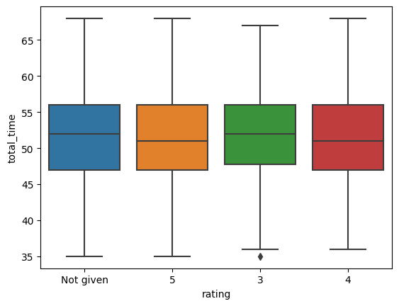

```python
#total_time food_prep+deliv_time

df['total_time'] = df['food_preparation_time']+df['delivery_time']

sns.boxplot(data=df,x='rating', y='total_time')
plt.show()
```

The ratings 3-5 have almost identical boxplots with similar ranges and 50% having a total time less than approximately 53 minutes. Notably, the 3 rating has outlier(s) in the lower margin of 35 minutes.

### **Question 13:** The company wants to provide a promotional offer in the advertisement of the restaurants. The condition to get the offer is that the restaurants must have a rating count of more than 50 and the average rating should be greater than 4. Find the restaurants fulfilling the criteria to get the promotional offer. [3 marks]

```python
# Determine all of the possible values within rating
df['rating'].unique()
```

```
array(['Not given', '5', '3', '4'], dtype=object)
```

```python
#Replace 'Not given' with nan so the data type can be converted to integer
df['rating'] = df['rating'].replace(['Not given'],np.nan)

#Convert data type to float
df['rating'] = df['rating'].astype(float)

#view change
df.info()
```

```
<class 'pandas.core.frame.DataFrame'>
RangeIndex: 1898 entries, 0 to 1897
Data columns (total 10 columns):
 #   Column                 Non-Null Count  Dtype
---  ------                 --------------  -----
 0   order_id               1898 non-null   int64
 1   customer_id            1898 non-null   int64
 2   restaurant_name        1898 non-null   object
 3   cuisine_type           1898 non-null   object
 4   cost_of_the_order      1898 non-null   float64
 5   day_of_the_week        1898 non-null   object
 6   rating                 1162 non-null   float64
 7   food_preparation_time  1898 non-null   int64
 8   delivery_time          1898 non-null   int64
 9   total_time             1898 non-null   int64
dtypes: float64(2), int64(5), object(3)
memory usage: 148.4+ KB
```

```python
#find average rating of each restaurant
avg_rating = df.groupby(['restaurant_name']).mean()['rating'].reset_index()
avg_rating.rename(columns={'rating':'avg_rating'},inplace=True)
avg_rating
```

|  | restaurant_name | avg_rating |
| --- | --- | --- |
| 0 | 'wichcraft | 5.000000 |
| 1 | 12 Chairs | 4.500000 |
| 2 | 5 Napkin Burger | 4.000000 |
| 3 | 67 Burger | 5.000000 |
| 4 | Alidoro | NaN |
| ... | ... | ... |
| 173 | Zero Otto Nove | 4.000000 |
| 174 | brgr | 3.000000 |
| 175 | da Umberto | 5.000000 |
| 176 | ilili Restaurant | 4.153846 |
| 177 | indikitch | 4.500000 |

178 rows × 2 columns

```python
#isolate restaurants with average ratings higher than 4
rating_4 = avg_rating[avg_rating['avg_rating']>4]
rating_4
```

|  | restaurant_name | avg_rating |
| --- | --- | --- |
| 0 | 'wichcraft | 5.000000 |
| 1 | 12 Chairs | 4.500000 |
| 3 | 67 Burger | 5.000000 |
| 5 | Amma | 4.500000 |
| 7 | Anjappar Chettinad | 5.000000 |
| ... | ... | ... |
| 171 | Yama 49 | 5.000000 |
| 172 | Yama Japanese Restaurant | 4.500000 |
| 175 | da Umberto | 5.000000 |
| 176 | ilili Restaurant | 4.153846 |
| 177 | indikitch | 4.500000 |

110 rows × 2 columns

```python
# create dataframe with rating counts
rating_count = df.groupby(['restaurant_name'])['rating'].count().reset_index()
rating_count.rename(columns={'rating':'rating_count'},inplace=True)
rating_count
```

|  | restaurant_name | rating_count |
| --- | --- | --- |
| 0 | 'wichcraft | 1 |
| 1 | 12 Chairs | 2 |
| 2 | 5 Napkin Burger | 2 |
| 3 | 67 Burger | 1 |
| 4 | Alidoro | 0 |
| ... | ... | ... |
| 173 | Zero Otto Nove | 1 |
| 174 | brgr | 1 |
| 175 | da Umberto | 1 |
| 176 | ilili Restaurant | 13 |
| 177 | indikitch | 2 |

178 rows × 2 columns

```python
#isolate restaurants with rating counts higher than 50
rating_count_50 = rating_count[rating_count['rating_count']>50]
rating_count_50
```

|  | restaurant_name | rating_count |
| --- | --- | --- |
| 20 | Blue Ribbon Fried Chicken | 64 |
| 21 | Blue Ribbon Sushi | 73 |
| 136 | Shake Shack | 133 |
| 153 | The Meatball Shop | 84 |

```python
#merge two data frames for the list of eligible restaurants that meet both criteria
df_eligible= rating_4.merge(rating_count_50, how= 'inner', on='restaurant_name')
df_eligible
```

|  | restaurant_name | avg_rating | rating_count |
| --- | --- | --- | --- |
| 0 | Blue Ribbon Fried Chicken | 4.328125 | 64 |
| 1 | Blue Ribbon Sushi | 4.219178 | 73 |
| 2 | Shake Shack | 4.278195 | 133 |
| 3 | The Meatball Shop | 4.511905 | 84 |

#### Observations:

The restaurants that are eligible for the promotional offer are Blue Ribbon Fried Chicken, Blue Ribbon Sushi, Shake Shack, and The Meatball Shop. These restaurants have ratings greater than 4 and counts greater than 50.

### **Question 14:** The company charges the restaurant 25% on the orders having cost greater than 20 dollars and 15% on the orders having cost greater than 5 dollars. Find the net revenue generated by the company across all orders. [3 marks]

```python
#Isolate all values of cost_of_the_order greater than $20
g20 = df['cost_of_the_order']>20
#Find the sum
sum_g20 = df[g20]['cost_of_the_order'].sum()
#Find the 25% revenue that FoodHub recieves from the sum greater than 20
rev20 = sum_g20*.25
rev20
```

```
3688.7275
```

```python
sum_g20
```

```
14754.91
```

```python
#Isolate all of the values cost_of_the_order greater than $5
g5 = df['cost_of_the_order']>5
#Remove values of greater than 20 from g5
sum_g5 = df[g5]['cost_of_the_order'].sum()
tot_g5 = sum_g5 - sum_g20
#Find the 15% revenue from the sum greater than 5 but less than 20
rev15 = tot_g5*0.15
rev15
```

```
2477.5755000000004
```

```python
net_revenue = rev15 + rev20
net_revenue
```

```
6166.303
```

```python
total = df['cost_of_the_order'].sum()
print('The total revenue of all orders is',total)
perc_net = (net_revenue/total)*100
print('The net revenue is',perc_net,'percent of the total')
```

```
The total revenue of all orders is 31314.82
The net revenue is 19.691325065895317 percent of the total
```

#### Observations:

The net revenue that FoodHub receieves from all orders is $6,166.30. This is 19.69 percent of the total revenue of all of the orders.

### **Question 15:** The company wants to analyze the total time required to deliver the food. What percentage of orders take more than 60 minutes to get delivered from the time the order is placed? (The food has to be prepared and then delivered.) [2 marks]

```python
#food_prep+deliv_time

df['total_time'] = df['food_preparation_time']+df['delivery_time']
above_60 = df.loc[df['total_time']>60]
(len(above_60)/len(df))*100
```

```
10.537407797681771
```

#### Observations:

The percentage of orders that take more than 60 minutes is 10.54% of the total orders.

### **Question 16:** The company wants to analyze the delivery time of the orders on weekdays and weekends. How does the mean delivery time vary during weekdays and weekends? [2 marks]

```python
# Write the code here
df.groupby(['day_of_the_week']).mean()[['total_time']]
```

| day_of_the_week | total_time |
| --- | --- |
| Weekday | 55.552102 |
| Weekend | 49.906736 |

### Conclusion and Recommendations

### **Question 17:** What are your conclusions from the analysis? What recommendations would you like to share to help improve the business? (You can use cuisine type and feedback ratings to drive your business recommendations.) [6 marks]

### Conclusions:

- American is the most popular cuisine by a wide margin
- Weekends seem to be the most popular days to use the service and have the shortest total delivery time
- Rating does not seem to have any strong correlation with any of the metrics available, this suggests that another reason is responsible for the rating
- There is great overlap between the top restaurants with the highest average rating and most orders
- Net revenue is comprised of nearly 20% the total revenue raked in from Foodhub

### Recommendations:

- Focus any promotions or discounts for the weekend, to further boost sales
- Collect more metrics behind the ratings given to understand why the service is liked or disliked
- Incentivize customers to give more ratings
- Add more American cuisine restaurants to the options as they are the most popular